# 02. 생존분석 소개

### 2-1 생존분석이란?

- **생존분석이란 어떤 사건이 일어날 때 까지의 시간을 관심있는 반응변수로 하는 통계적인 방법**
- **시간** : 한 개인을 추적하기 시작하면서부터 어떤 사건이 일어날 때 까지의 며칠, 몇 개월, 몇 년에 걸친 기간을 의미 (때로는 연령이 시간이 되기도 함)
- **사건** : 사망, 질병의 발생, 재발, 회복 또는 어떤 사람에게 일어날 수 있는 관심 있는 경험
- 하나의 여구에서 여러 개의 사건이 발생할 수도 있지만, 보통 하나의 사건만이 일어나는 것으로 가정하고 분석을 진행
- 생존분석에서는 시간변수를 '생존시간'이라고 표현하며, 사건의 발생을 '실패'로 표현 (보통 관심이 있는 사건이 사망이나 질병의 발생, 재발 또는 좋지 않은 경험인 경우가 대부분)

### 생존시간

**생존시간(Survival time) : 어떤 정의된 시점부터 특정한 사건(event)가 발생할 때까지의 시간을 의미한다. 따라서 항상 양(Positive)의 값을 갖고 매우 치우친 분포를 가짐**

### 2-2 자료의 중도절단

- 대부분의 생존분석에서 중요한 문제는 자료의 중도절단(censoring)
- 중도절단 자료는 생존 시간에 대한 어느 정도의 정보는 가지고 있지만, 정확한 생존시간을 모를 때 발생
  - 예 : 백혈병 환자를 대상으로 관해상태에 들어간 후, 재발할 때 까지 관찰하는 연구에서 연구 종료 시점까지 환자가 관해상태를 유지한다면, 환자의 생존시간은 중도절단된 것
  - 중도절단 발생의 3가지 이유 :
    1. 연구 종료 시까지 사건이 일어나지 않은 경우
    2. 연구 기간동안 추적관찰에 실패한 경우
    3. 환자가 사망(사망이 관찰하고자 하는 사건이 아닌 경우)이나 다른 이유로(약물 부작용이나 다른 경쟁위험 때문에) 탈락한 경우

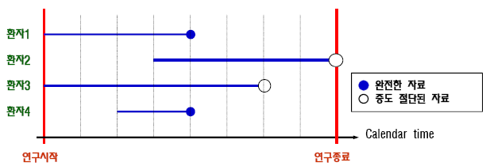

- **4명의 환자중에서 2명이 중도 절단**
- **환자2번은 연구종료 시점까지 event가 발생하지 않았기 때문에, 환자3번은 중간에 다른 어떤 이유로 데이터를 얻을 수 없어 중도 절단**
- **환자2, 3는 연구종료까지 이벤트가 발생하지 않았거나, 중도에 탈락하여 정확한 생존시간을 알 수 없는 경우로 우중도절단(right-censored)자료** (대부분의 생존자료는 우중도절단)
- **관찰된 생존시간보다 실제 생존기간이 짧은 경우 좌중도절단(left-censored)자료**

| 이름 | 생존시간 | 상태 |
| --- | --- | --- |
| 환자1 | 4.0 | 1 |
| 환자2 | 5.0 | 0 |
| 환자3 | 6.0 | 0 |
| 환자4 | 2.0 | 1 |

(중도절단된 자료는 상태가 0, 이벤트가 발생한 자료는 1)

#### 좌중도 절단

- **어떤 사람이 시간 t에서 좌중도절단 되었다고 하는 것은, 사건의 발생이 0과 t사이에 있었다는 것은 알지만, 정확한 시간은 모르는 경우**

#### 구간중도절단(interval-censored)

- 실제 생존시간이 어떤 구간 내에 발생하는 경우
- **t1에서 음성이 나오고, t2에서 양성으로 나왔지만, 정확한 바이러스 감염시간을 알지 못 할 경우, 시간구나 [t1, t2]사이에서 구간중도절단**

### 2-3 용어와 표기

- **`T`** : 어떤 개인의 생존시간을 의미하는 확률변수 (random variable)로 시간을 표현 (양수)
- **`t`** : 생존시간 `T`중 관심있는 특정한 값을 표현

  예 : 수술 이후 5년 이상 생존하였는지 (Survival > 5years) 평가하고자 한다면, $t = 5$이며, $T > t = 5$인지 평가
- **`d`** : 중도절단 또는 실패를 의미하는 무작위 변수 ($d = 0$ : 중도절단 / $d = 1$ : 사건발생(실패))
  - 연구 대상자에게 이벤트가 발생하지 않은 경우 항상 중도절단
  - $d=0$인 경우, 연구 종료 시까지 환자가 생존하거나 추적에 실패한 경우 (또는 중도 탈락)

### 생존함수 (Survivor function, `S(t)`)

- 특정시간 $t$보다 오래 생존할 확률 => **생존시간 $T$가 특정한 시간 $t$보다 클 확률을 의미**

#### $S(t) = P(T > t) = 1 - P(T \leq t)$, [$0 < t < \infty$]

- **[$t, \infty$]의 구간에서 생존함수는 이론적으로 매끈한 곡선으로 나타남. 하지만 실제 연구에 있어서는 계단 형태**
- 생존함수는 감소함수
- **$t = 0$일 때, $S(t) = S(0) = 1$**. 즉 연구가 시작되었을 때, 아직 이벤트가 일어나지 않았으므로 생존함수는 1
- **$t = \infty$일 때, $S(t) = S(\infty) = 0$**. 즉 이론적으로는 연구 기간의 제한이 없다면, 결국 모든 대상자가 사망하므로 생존함수는 0
  - 단, 모든 연구 대상자에게 이벤트가 생기지는 않을 수도 있기 때문에, 연구 종료 시 추정생존함수 $\hat{S}(t)$가 반드시 0이 되지는 않음

### 위험함수 (hazard function, `h(t)`)

- **어떤 대상이 특정한 시간 $t$이상 생존하였다고 가정할 때**, $t$로부터 아주 짧은 시간 간격안에 실패할 확률을 그 짧은 시간 간격으로 나눈 것 (**순간적인 실패율**)
- **위험함수는 시간 $t$에 대하여**
  - **항상 양수**
  - **0부터 무한대의 값을 가짐**

**($\Delta t$ = 시간간격)**

| P | $\Delta t$ | $P/\Delta t = rate$ |
| --- | --- | --- |
| 1 / 3 | 1 / 2 day | $(1 / 3)\;\div\;(1/2)\;=\;0.67\;/\;day$ |
| 1 / 3 | 1 / 14 week | $(1 / 3)\;\div\;(1/14)\;=\;4.67\;/\;week$ |

#### 생존분포의 다른 용어

**1. 누적분포함수 (CDF, $F(t)$)**

#### $F(t) = P(T \leq t) = 1 - S(t),\;\;[0 < t < \infty]$

**2. 확률밀도함수 (PDF, $f(t)$) : CDF의 변화율**

#### $f(t) = {d \over {dt}}F(t) = -{d \over {dt}}S(t)$

- 위험함수는 PDF 및 생존함수와 관계가 있으며, 다음과 같이 표현

#### $h(t) = {f(t) \over {S(t)}}$

- 누적위험함수는 위험함수 아래의 면적을 특정시간 $t$까지 적분

#### $H(t) = \int^{t}_{0} h(u)\;du$

### 생존함수와 위험함수간의 관계

### $S(t)=exp\;[-\int^{t}_{0}h(u)du]\;=\;exp(-H(t))$

### $h(t)\;=\;-{}{{dS(t)\;/\;dt}\over{S(t)}}\;=\;-{S^{'}(t) \over {S(t)}}\;=\;-{d \over dt}\;log(S(t))$

### 생존분석의 목표

1. **생존데이터로부터 생존함수와 위험함수를 추정**
2. **생존함수와 위험함수를 비교**
3. **설명변수와 생존시간의 관계를 평가**

### 선형회귀 및 로지스틱 회귀와의 차이

| 모형 | 반응변수 | 효과추정 |
| --- | --- | --- |
| 생존분석 | time to event (이벤트 발생까지의 시간, with censoring) | Hazard ratio $e^\beta$ |
| 선형회귀 | 연속형변수 (정규분포) | 회귀계수 $\beta$ |
| 로지스틱회귀 | 이진변수 (이항분포) | Odds ratio $e^\beta$ |